# Babylab eye tracker data - Data cleaning

# 5 Qualité du signal

Qualité du signal d’un essai = N fixations de qualité 1 / N total de fixations.

Qualité de signal d’une tache = moyenne des qualité de signal de chaque essai retenu c’est à dire le pourcentage de bonnes fixations de la tache. Moins l’enfant regarde l’écran, plus cet indice est bas (tourne la tête, bouge, etc).

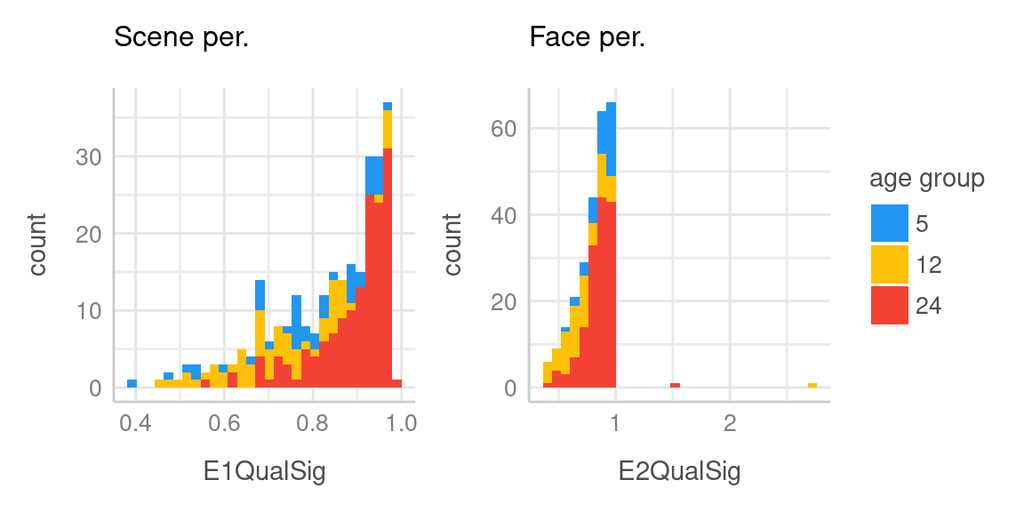

- QualSig > 1: **SERA CORRIGE DANS LA PROCHAINE VERSION DE LA BASE, ERREUR DE CODE COTE DAVID** (cf échange tel avec lui le 14/12/20)

Distributions **sans les 2 essais avec QualSig > 1**:

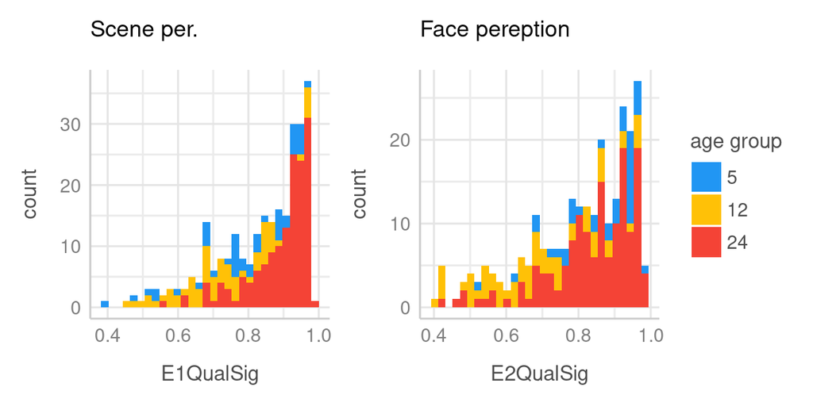

# 6 Temps moyen de regard

Somme des temps de fixation pour les fixations de qualité de fixation == 1 divisé par le nombre d’essai retenus.

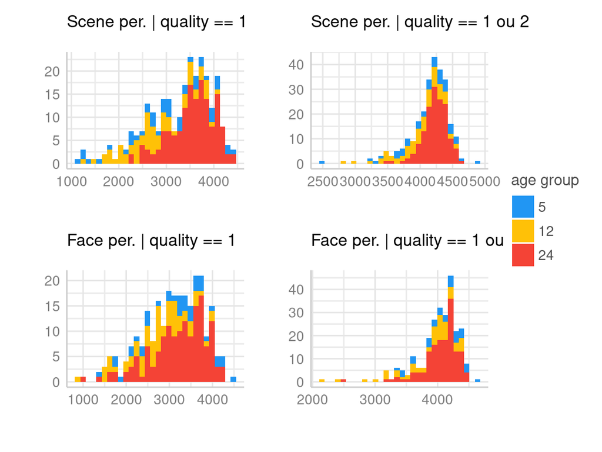

- **Tous les temps < au temps de l’essai de 5 sec** => OK
- **Temps les plus bas pour enfants < 24m**
- A-t-on besoin de faire un descriptif plus poussé des temps bas? => D’après David non, c’est possible

Pourcentage de temps moyen regard en dessous de 30% du temps total regardé (aka pourcentage de temps moyen de regard / 5sec < 0.3):

Tâche de perception de scene:

```
##        age
## t1_30     5  12  24
##   FALSE  42  65 151
##   TRUE    4   2   0
```

- 0 enfants de 24m avec < 30% de temps à regarder l’écran à la tâche 1

Tache de perception de visage:

```
##        age
## t2_30     5  12  24
##   FALSE  38  64 148
##   TRUE    1   2   2
```

```
## # A tibble: 5 x 3
## # Groups:   ident [5]
##   ident exp_age_cat t2_look_pct
##   <chr> <fct>             <dbl>
## 1 25119 5                 0.280
## 2 17886 24                0.204
## 3 26469 12                0.165
## 4 26806 12                0.291
## 5 25130 24                0.286
```

- 2 enfants de 24m avec < 30% de temps à regarder l’écran à la tâche 2 (20% et 28%)

Qu’en fait-on? D’après David OK de les garder.

# 7 Conclusions

A priori pas besoin d’exclure d’enfants sur ces données.

- Un score calculé sur un nombre réduit d’essais n’ets pas faux, il est juste moins précis (plus de bruit de mesure)
- Il n’y a pas de signal avec qualité trop basse car un étape préalable de filtrage des données a été effectuée (essais avec q_sig < 0.2 déjà exclus par David)
- Un temps de regard faible est possible, d’autant que l’on va utiliser cette variable dans nos analyses donc pas de raison de les exclure